# Space Titanic

Bryan Hatami and Aidan Molina

#Problem and Data Description

Space Titanic:

Problem:

We want to predict whether or not each passenger is going to be transported or not to an alternate dimension during the Spaceship Titanic’s collision with the space time anomaly.

Data Description:

The variables in the data that we are given are: PassengerID, HomePlanet (what planet they departed from), CryoSleep (whether or not the passenger is in cryo sleep for the duration of the trip), Cabin (deck number, room number, and starboard or port side of the ship), Destination, Age, and VIP. RoomService, ShoppingMall, Spa, FoodCourt, and VRDeck, which all dictate how much money the person has spent on their trip. Finally the passenger’s Name. All of these variables are then used to predict the last variable of Transported, to determine whether or not they were transported to an alternate dimension. We have ~13,000 total data points, with ~8,700 of them as a part of our training data, and ~4,300 of them as a part of our test data which we will be filling in the Transported variable.

#DATA PROCESSING

R Studio allows alot of built in packages that help

Below one can see how we loaded helpful packages in this enviorment

```r
library(ggthemes)
library(ggcorrplot)
library(tidyverse)
homeFile <- file.path("..","input","spaceship-titanic")
list.files(path = homeFile)
```

```
## character(0)
```

```r
theme_set(theme_get() + theme(text = element_text(size = 30)))
```

(Split cabin into three parts: Deck, Number and Side )

(Create spent field that holds: RoomService + FoodCourt + ShoppingMall + Spa + VRDeck Change Transported)

(CryoSleep & VIP: T/F to 1 and 0 respectfully)

(Remove: the name field as it doesn’t affect data)

```r
train <-
    read_csv("train.csv") %>%
    separate(Cabin, into=c('Deck', 'Room', 'Side'), sep="/") %>%
    mutate(Spent = RoomService + FoodCourt + ShoppingMall + Spa + VRDeck) %>%
    mutate(VarTrans = ifelse(Transported, 1, 0),
           VarCrySleep = ifelse(CryoSleep, 1, 0),
           VarVIP = ifelse(VIP, 1, 0)) %>%
    select(PassengerId:CryoSleep, VarCrySleep, Deck:VIP,
          VarVIP, RoomService:VRDeck, Spent,Transported, VarTrans)
head(train)
```

```
## # A tibble: 6 × 19
##   PassengerId HomePlanet CryoSleep VarCrySleep Deck  Room  Side  Destination
##   <chr>       <chr>      <lgl>           <dbl> <chr> <chr> <chr> <chr>
## 1 0001_01     Europa     FALSE               0 B     0     P     TRAPPIST-1e
## 2 0002_01     Earth      FALSE               0 F     0     S     TRAPPIST-1e
## 3 0003_01     Europa     FALSE               0 A     0     S     TRAPPIST-1e
## 4 0003_02     Europa     FALSE               0 A     0     S     TRAPPIST-1e
## 5 0004_01     Earth      FALSE               0 F     1     S     TRAPPIST-1e
## 6 0005_01     Earth      FALSE               0 F     0     P     PSO J318.5-22
## # … with 11 more variables: Age <dbl>, VIP <lgl>, VarVIP <dbl>,
## #   RoomService <dbl>, FoodCourt <dbl>, ShoppingMall <dbl>, Spa <dbl>,
## #   VRDeck <dbl>, Spent <dbl>, Transported <lgl>, VarTrans <dbl>
```

```r
spec(train)
```

```r
train
```

```
## # A tibble: 8,693 × 19
##    PassengerId HomePlanet CryoSleep VarCrySleep Deck  Room  Side  Destination
##    <chr>       <chr>      <lgl>           <dbl> <chr> <chr> <chr> <chr>
##  1 0001_01     Europa     FALSE               0 B     0     P     TRAPPIST-1e
##  2 0002_01     Earth      FALSE               0 F     0     S     TRAPPIST-1e
##  3 0003_01     Europa     FALSE               0 A     0     S     TRAPPIST-1e
##  4 0003_02     Europa     FALSE               0 A     0     S     TRAPPIST-1e
##  5 0004_01     Earth      FALSE               0 F     1     S     TRAPPIST-1e
##  6 0005_01     Earth      FALSE               0 F     0     P     PSO J318.5-22
##  7 0006_01     Earth      FALSE               0 F     2     S     TRAPPIST-1e
##  8 0006_02     Earth      TRUE                1 G     0     S     TRAPPIST-1e
##  9 0007_01     Earth      FALSE               0 F     3     S     TRAPPIST-1e
## 10 0008_01     Europa     TRUE                1 B     1     P     55 Cancri e
## # … with 8,683 more rows, and 11 more variables: Age <dbl>, VIP <lgl>,
## #   VarVIP <dbl>, RoomService <dbl>, FoodCourt <dbl>, ShoppingMall <dbl>,
## #   Spa <dbl>, VRDeck <dbl>, Spent <dbl>, Transported <lgl>, VarTrans <dbl>
```

We then Get the Summary of the train data

```r
summary(train)
```

```
##  PassengerId         HomePlanet        CryoSleep        VarCrySleep
##  Length:8693        Length:8693        Mode :logical   Min.   :0.0000
##  Class :character   Class :character   FALSE:5439      1st Qu.:0.0000
##  Mode  :character   Mode  :character   TRUE :3037      Median :0.0000
##                                        NA's :217       Mean   :0.3583
##                                                        3rd Qu.:1.0000
##                                                        Max.   :1.0000
##                                                        NA's   :217
##      Deck               Room               Side           Destination
##  Length:8693        Length:8693        Length:8693        Length:8693
##  Class :character   Class :character   Class :character   Class :character
##  Mode  :character   Mode  :character   Mode  :character   Mode  :character
##
##
##
##
##       Age           VIP              VarVIP         RoomService
##  Min.   : 0.00   Mode :logical   Min.   :0.00000   Min.   :    0.0
##  1st Qu.:19.00   FALSE:8291      1st Qu.:0.00000   1st Qu.:    0.0
##  Median :27.00   TRUE :199       Median :0.00000   Median :    0.0
##  Mean   :28.83   NA's :203       Mean   :0.02344   Mean   :  224.7
##  3rd Qu.:38.00                   3rd Qu.:0.00000   3rd Qu.:   47.0
##  Max.   :79.00                   Max.   :1.00000   Max.   :14327.0
##  NA's   :179                     NA's   :203       NA's   :181
##    FoodCourt        ShoppingMall          Spa              VRDeck
##  Min.   :    0.0   Min.   :    0.0   Min.   :    0.0   Min.   :    0.0
##  1st Qu.:    0.0   1st Qu.:    0.0   1st Qu.:    0.0   1st Qu.:    0.0
##  Median :    0.0   Median :    0.0   Median :    0.0   Median :    0.0
##  Mean   :  458.1   Mean   :  173.7   Mean   :  311.1   Mean   :  304.9
##  3rd Qu.:   76.0   3rd Qu.:   27.0   3rd Qu.:   59.0   3rd Qu.:   46.0
##  Max.   :29813.0   Max.   :23492.0   Max.   :22408.0   Max.   :24133.0
##  NA's   :183       NA's   :208       NA's   :183       NA's   :188
##      Spent       Transported        VarTrans
##  Min.   :    0   Mode :logical   Min.   :0.0000
##  1st Qu.:    0   FALSE:4315      1st Qu.:0.0000
##  Median :  736   TRUE :4378      Median :1.0000
##  Mean   : 1485                   Mean   :0.5036
##  3rd Qu.: 1486                   3rd Qu.:1.0000
##  Max.   :35987                   Max.   :1.0000
##  NA's   :908
```

#Handling Missing Values

First thing we want to do is find what columns hold missing values and how many each hold

```r
missing_cols <- which(colSums(is.na(train))>0)
missing_cols
```

```
##   HomePlanet    CryoSleep  VarCrySleep         Deck         Room         Side
##            2            3            4            5            6            7
##  Destination          Age          VIP       VarVIP  RoomService    FoodCourt
##            8            9           10           11           12           13
## ShoppingMall          Spa       VRDeck        Spent
##           14           15           16           17
```

```r
for(i in missing_cols){
  print(colnames(train[i]))
  print(sum(is.na(train[,i])))
}
```

```
## [1] "HomePlanet"
## [1] 201
## [1] "CryoSleep"
## [1] 217
## [1] "VarCrySleep"
## [1] 217
## [1] "Deck"
## [1] 199
## [1] "Room"
## [1] 199
## [1] "Side"
## [1] 199
## [1] "Destination"
## [1] 182
## [1] "Age"
```

[output cut: 17 more lines]

We then change the missing values to be replaced with the most common value that the column holds either by mode function or sort table function

```r
getmode <- function(v) {
 uniqv <- unique(v)
 uniqv[which.max(tabulate(match(v, uniqv)))]
}


train[["HomePlanet"]][is.na(train[["HomePlanet"]])] <- tail(names(sort(table(train$HomePlanet))), 1)
train[["CryoSleep"]][is.na(train[["CryoSleep"]])] <- tail(names(sort(table(train$CryoSleep))), 1)
train[["VarCrySleep"]][is.na(train[["VarCrySleep"]])] <- as.numeric(getmode(train$VarCrySleep))
train[["Deck"]][is.na(train[["Deck"]])] <- tail(names(sort(table(train$Deck))), 1)
train[["Room"]][is.na(train[["Room"]])] <- as.numeric(getmode(train$Room))
train[["Side"]][is.na(train[["Side"]])] <- tail(names(sort(table(train$Side))), 1)
train[["Destination"]][is.na(train[["Destination"]])] <- tail(names(sort(table(train$Destination))), 1)
train[["Age"]][is.na(train[["Age"]])] <- as.numeric(getmode(train$Age))
train[["VIP"]][is.na(train[["VIP"]])] <- tail(names(sort(table(train$VIP))), 1)
train[["VarVIP"]][is.na(train[["VarVIP"]])] <- as.numeric(getmode(train$VarVIP))
train[["RoomService"]][is.na(train[["RoomService"]])] <- as.numeric(getmode(train$RoomService))
train[["FoodCourt"]][is.na(train[["FoodCourt"]])] <- as.numeric(getmode(train$FoodCourt))
train[["ShoppingMall"]][is.na(train[["ShoppingMall"]])] <- as.numeric(getmode(train$ShoppingMall))
train[["Spa"]][is.na(train[["Spa"]])] <- as.numeric(getmode(train$Spa))
train[["VRDeck"]][is.na(train[["VRDeck"]])] <- as.numeric(getmode(train$VRDeck))
train[["Spent"]][is.na(train[["Spent"]])] <- as.numeric(getmode(train$Spent))
train[["VarTrans"]][is.na(train[["VarTrans"]])] <- as.numeric(getmode(train$VarTrans))
```

#Exploratory Data Analysis

Look at the Transported against CryoSleep with a geometric bar plot

```r
table(train$CryoSleep, train$Transported)
```

```
##
##         FALSE TRUE
##   FALSE  3761 1895
##   TRUE    554 2483
```

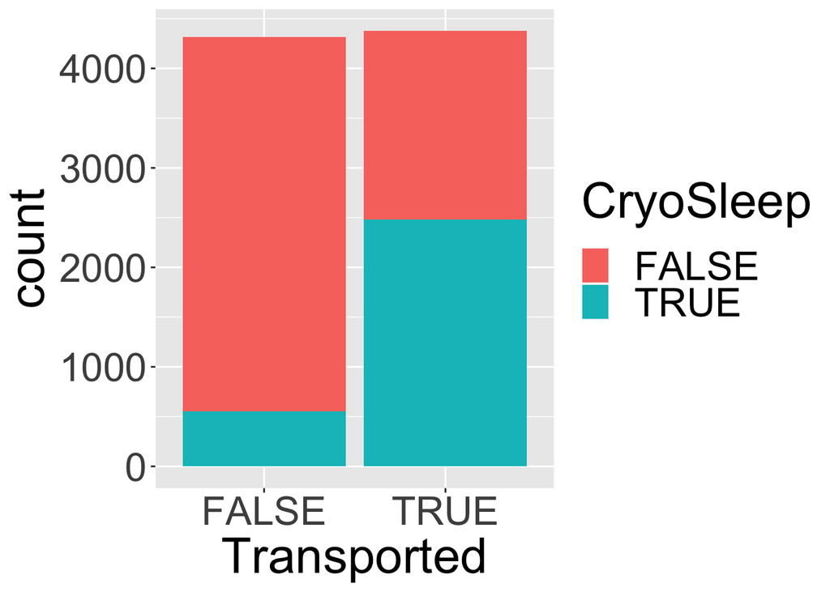

```r
options(repr.plot.width = 25)
train %>% ggplot(aes(x=Transported, fill=CryoSleep)) + geom_bar()
```

Looking at the Transported individuals against the Amount they spent across the board with a box plot

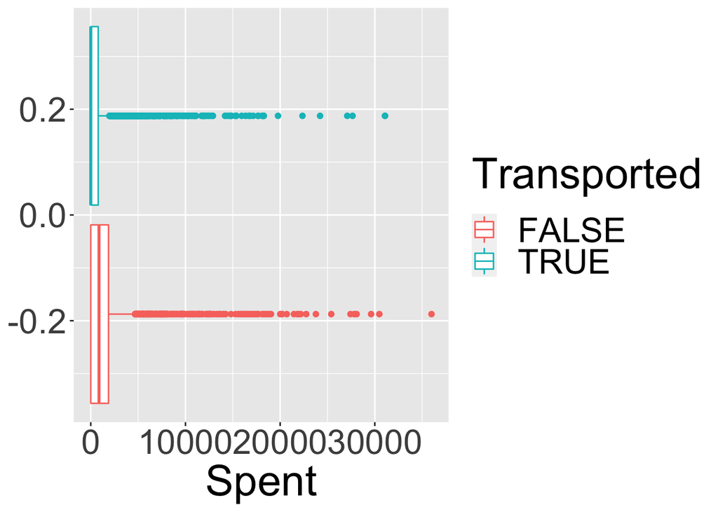

```r
options(repr.plot.width = 48, repr.plot.height = 15)

train %>% ggplot(aes(x=Spent, color=Transported)) + geom_boxplot()
```

Look at the data from the Side and the Deck with a table

```r
table(train$Side, train$Deck)
```

```
##
##        A    B    C    D    E    F    G    T
##   P  117  353  341  248  429 1438 1276    4
##   S  139  426  406  230  447 1555 1283    1
```

Looking at the Transported individuals against the Deck they were on with a table

```r
table(train$Transported, train$Deck)
```

```
##
##            A    B    C    D    E    F    G    T
##   FALSE  129  207  239  271  563 1664 1238    4
##   TRUE   127  572  508  207  313 1329 1321    1
```

Looking at the Transported individuals against the Side they were on with a table

```r
table(train$Transported, train$Side)
```

```
##
##            P    S
##   FALSE 2308 2007
##   TRUE  1898 2480
```

Home Planet and Destination

Looking at the Transported individuals against their Home Planet with a table

```r
table(train$Transported, train$HomePlanet)
```

```
##
##         Earth Europa Mars
##   FALSE  2749    727  839
##   TRUE   2054   1404  920
```

Looking at the Transported individuals against their Destination with a table

```r
table(train$Transported, train$Destination)
```

```
##
##         55 Cancri e PSO J318.5-22 TRAPPIST-1e
##   FALSE         702           395        3218
##   TRUE         1098           401        2879
```

Looking at the Home Planet of individuals against their Destination with a table

```r
table(train$Destination, train$HomePlanet)
```

```
##
##                 Earth Europa Mars
##   55 Cancri e     721    886  193
##   PSO J318.5-22   728     19   49
##   TRAPPIST-1e    3354   1226 1517
```

Age Data

Looking at the Transported individuals against their Age with a histogram

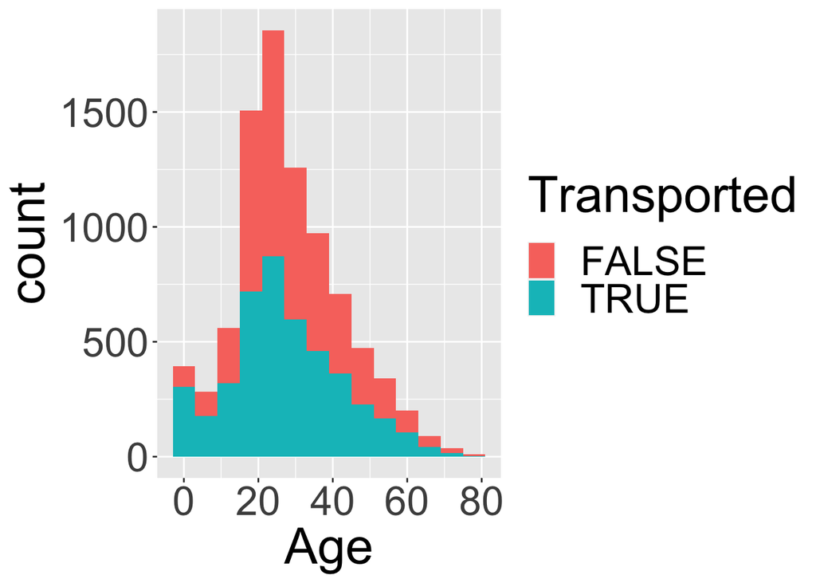

```r
options(repr.plot.width = 50, repr.plot.height = 32)
agePlots <- train %>%
    ggplot(aes(x=Age, fill=Transported)) +
    geom_histogram(binwidth=6) +
    theme(text = element_text(size = 31))
agePlots
```

Looking at the Age of an individual against the Home Planet they are from

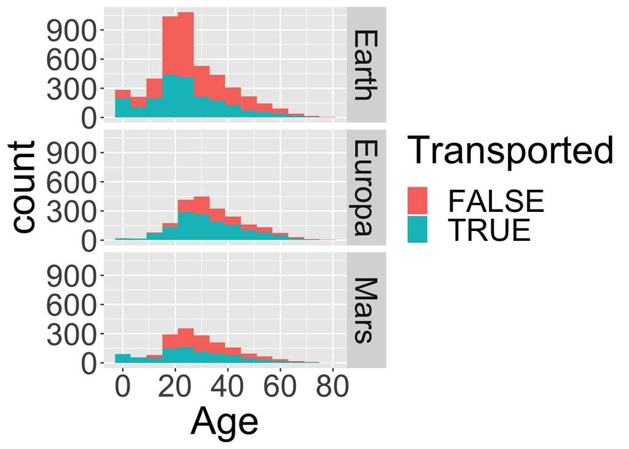

```r
agePlots + facet_grid(HomePlanet ~ .)
```

Looking at the Age of an individual against the Side they were on

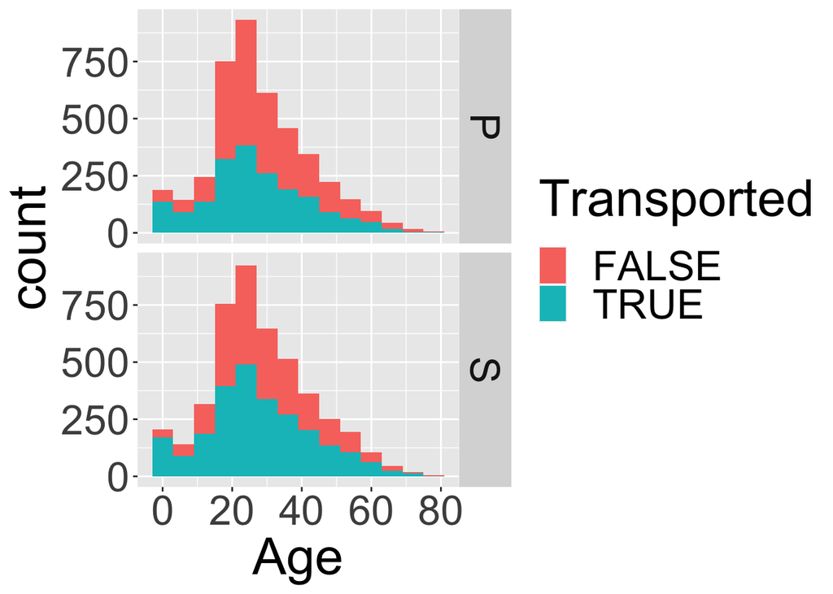

```r
agePlots + facet_grid(Side ~ .)
```

Looking at the Age of an individual against the Deck they were on

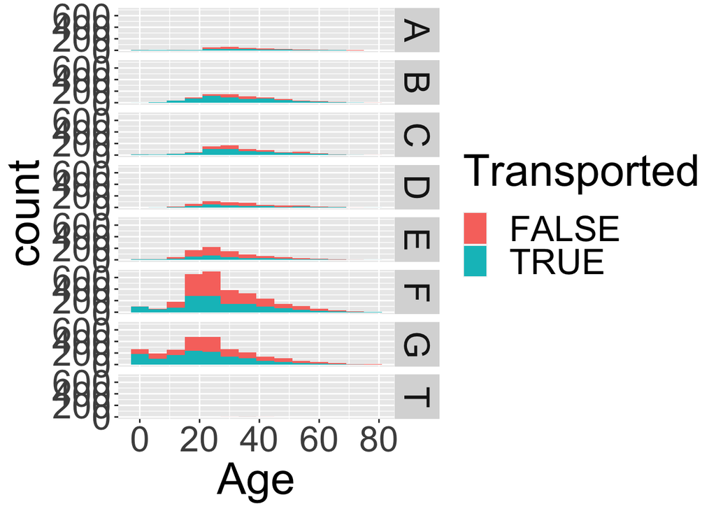

```r
agePlots + facet_grid(Deck ~ .)
```

Looking at the Age of an individual against their Destination

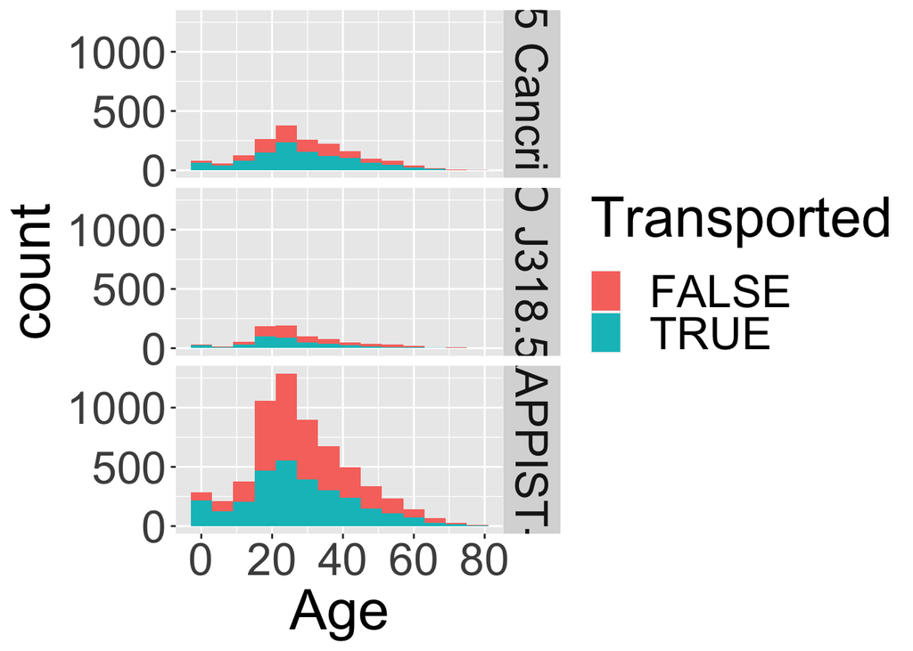

```r
agePlots + facet_grid(Destination ~ .)
```

Looking at the Age of an individual against if they were VIP or not

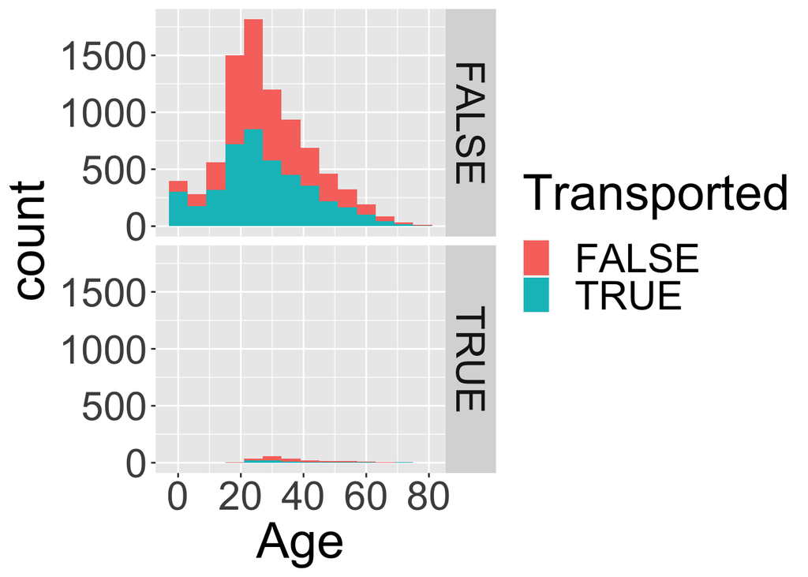

```r
agePlots + facet_grid(VIP ~ .)
```

Correlation between all the values

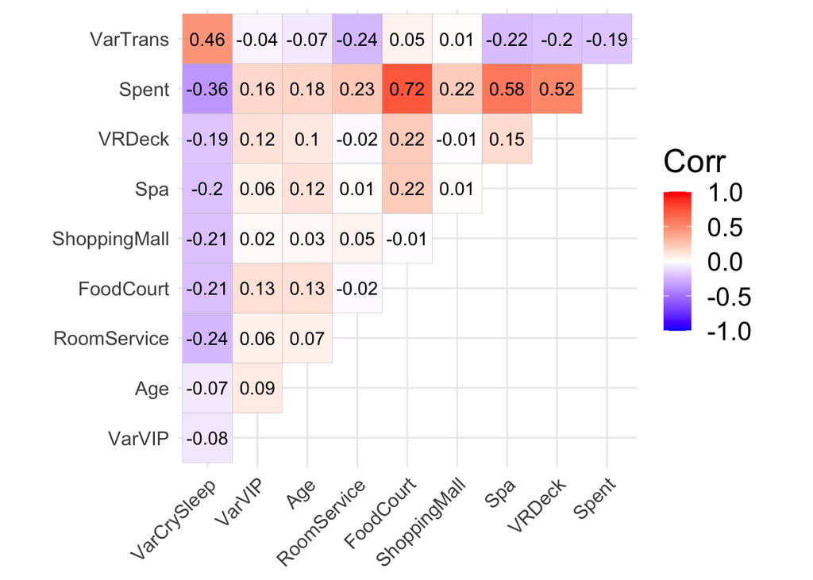

```r
corlationBeween <-
    train %>% select('VarCrySleep','VarVIP','Age','RoomService', 'FoodCourt','ShoppingMall','Spa','VRDeck','Spent','VarTrans') %>% cor()
ggcorrplot(corlationBeween, type="upper", lab=TRUE) + theme(text = element_text(size = 20))
```

#Algorithm and Methodology

For this section we used basic algorithms. To stop NAs from affecting the data we used a mode function to find the most common numeric value in the column to replace it with and we use a sort function to find the most common value in a column to replace it with. We used R bulit in plot functions to set the data against each other so that we could get a good understanding of what values will be the most important to look at when predicting what passangers were transported

#Experiments and Results

When looking at the experiments we ran earlier we can see a few things about the data.

Then we looked at the Transported individuals against the Amount they spent across the board by making a box plot where one can see those who were transported trended to spend less but the margin wasnt large.

We then looked at the data from the Side and the Deck by making a table and we could see that these values were pretty even on both sides on the spaceship.

Then we looked at the Transported individuals against the Deck they were on by making a table and noticed that on dec A, D and G there was little difference, Dec B and C more than half got transported, and dec E F and T had majorty of individuals not transported.

Then we looked at the Transported individuals against the Side they were on by a table and noticed that majority of individuals on P didnt transport but majority on S did.

The we Looked at the Transported individuals against their Destination by a table and noticed that majority of people travling to 55 Cancri e were transported while PSO J318.5-22 was more even and TRAPPIST-1e had a majorty of people not transported.

Then we looked at the Home Planet of individuals against their Destination by a table and we noticed that majority of people on Earth were traveling to TRAPPIST-1e and the same for the other planets as well. Europa and Mars both had a large difference in travel between 55 Cancri e and PSO J318.5-22 with majority traveling to 55 Cancri e.

We then Looked at the Transported individuals against their Age by a histogram plot and noticed that there was majority of people around the age of 20-25 and those individuals also had the highest amount to not be transported.

Then we looked at the Age of an individual against the Side they were on by a histogram plot and again saw the age of 20-25 having the hightest amount of people not transported and population.

We then looked at the Age of an individual against if they were VIP or not by a historgram and noticed that alot less people were vip on the spaceship and the data from peoples age being transported had the same outcome.

When looking at the Age of an individual against their Destination its seems that the again majoity of those who were not transported were from the ages of 20-25 but Trappist-1e had the biggest difference while 55 Cancri e & PSO J318.5-22 were closer to being even.

The we got the correlation between all the values by looking at the numeric data in a cor plot. From here we noticed that being transported a being in cryosleep have a strong correlation, how much one spend and the food court, spa and vrdeck have a string correlation but they don’t have a strong correlation between being transported.

#Summary and Conclusions

To summarize this section we could say that there is some strong correlation between certain data points and if they were transported or not. We saw that majority of people in Cyposleep were transported, that the amount they spent played a role but not too large, that the side one was one seemed to have an affect, that certain side of the deck one was on could have played a role, the planet one was traveling to played a role, the age they are played a role and the planet they were from played a role, and if they were in cryosleep played a large role.

#Acknowledgments

Kaggle - files and data

https://www.kaggle.com/competitions/spaceship-titanic/overview

Help with understanding on how to start and what to look for in the data set and to help with code on graphs/plots

https://www.kaggle.com/code/negoto/r-accurate-glm-aglm-on-spaceship-titanic